# PA1_template.Rmd

Mark Wan

10/14/2020

## **Overview**

This is a R Markdown document for Peer Assignment 1 of Week 2 of Module 5 - Reproducible Research. Goal of this assignment is to explore and familiarize use of R Markdown and knitr.

### **Loading and preprocessing the data**

1. **Code for reading in the dataset and/or processing the data**

```r
if(!file.exists('activity.csv')){
    unzip('activity.zip')
}
act <- read.csv("activity.csv",colClasses=c("numeric","character", "numeric"))
act$date <- as.Date(act$date, "%Y-%m-%d")
```

### **What is mean total number of steps taken per day?**

2. **Histogram of the total number of steps taken each day**

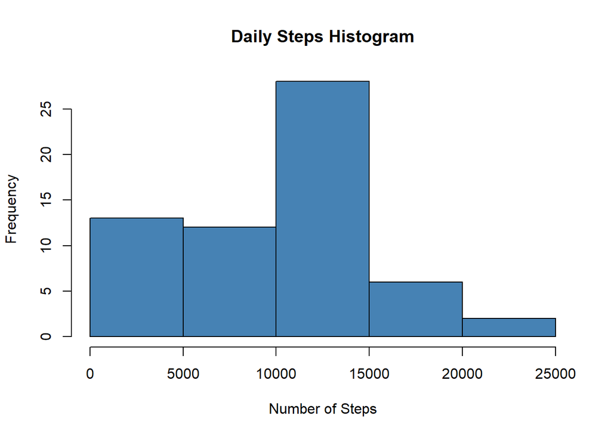

```r
tl1 <- with(act,tapply(steps,date,sum,na.rm=TRUE))
tl1_df <- data.frame(date=rownames(tl1),steps=tl1)
rownames(tl1_df) <- seq(1,nrow(tl1_df))
with(tl1_df,hist(tl1_df$steps, main="Daily Steps Histogram",col="steelblue",xlab="Number of Steps"))
```

3. **Mean and median number of steps taken each day**

```r
mn <- mean(tl1_df$steps)
md <- median(tl1_df$steps)
```

The mean number of steps is $9354.23$ (2dp). The median number of steps is $10395$ (2dp).

### **What is the average daily activity pattern?**

4. **Time series plot of the average number of steps taken**

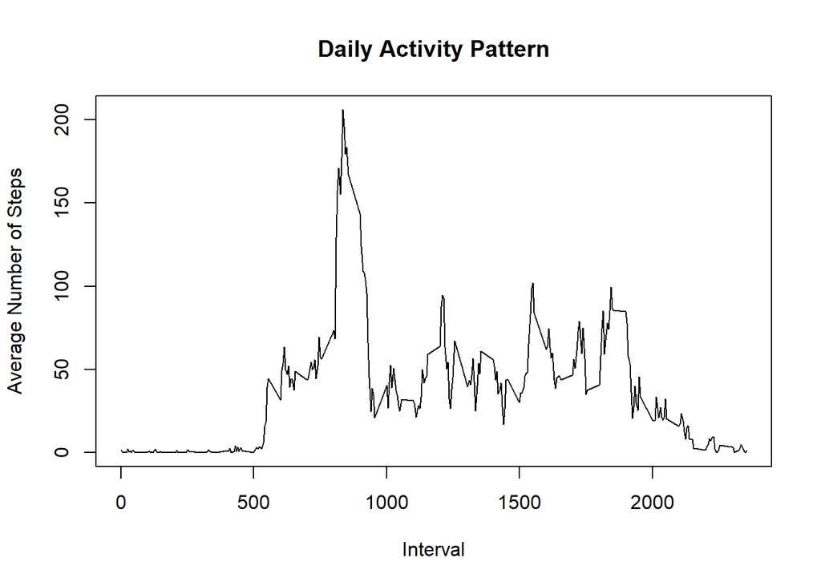

```r
mn1 <- with(act,tapply(steps,interval,mean,na.rm=TRUE))
mn1_df <- data.frame(interval=rownames(mn1),steps=mn1)
rownames(mn1_df) <- seq(1,nrow(mn1_df))
with(mn1_df,plot(interval,steps,type='l',main="Daily Activity Pattern",xlab="Interval",ylab = "Average Number of Steps"))
```

```r
max_steps <- max(mn1_df$steps)
idx <- with(mn1_df, which(steps==max_steps))
max_steps_interval <- mn1_df[idx,"interval"]
```

### **Imputing missing values**

```r
na_count <- with(act,sum(is.na(steps)))
```

Total number of rows with NAs is 2304

6. **Code to describe and show a strategy for imputing missing data**

NA steps will be filled with the mean number of steps for each interval.

Note: I used a ‘for’ loop together with chain indexing to 1) extract NA values and 2) replace NA values with group means. I do realize that this is not optimal and that there are better ways of implementing this imputation strategy (eg. impute() function with Hmisc). I only went down this path to understand the process of imputation by group.

```r
act_split <- split(act,act$interval)
for (i in names(act_split)) {
  act_split[as.character(i)][[1]]$steps[which(is.na(act_split[as.character(i)][[1]]$steps))] <- mean(act_split[as.character(i)][[1]]$steps,na.rm=TRUE)
}
```

```r
act_imputed <- do.call(rbind,c(act_split,make.row.names = FALSE))
library(knitr)
kable(head(act_imputed))
```

| steps | date | interval |
| --- | --- | --- |
| 1.716981 | 2012-10-01 | 0 |
| 0.000000 | 2012-10-02 | 0 |
| 0.000000 | 2012-10-03 | 0 |
| 47.000000 | 2012-10-04 | 0 |
| 0.000000 | 2012-10-05 | 0 |
| 0.000000 | 2012-10-06 | 0 |

7. **Histogram of the total number of steps taken each day after missing values are imputed**

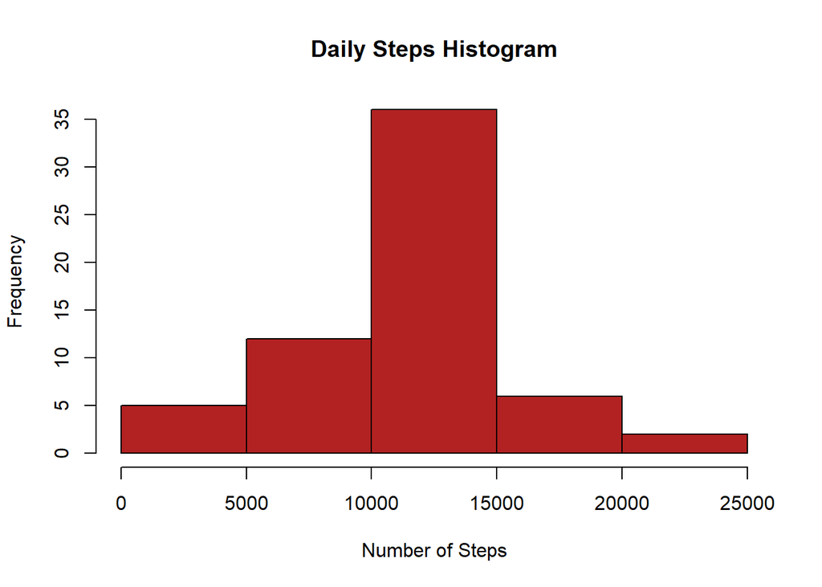

```r
tl2 <- with(act_imputed,tapply(steps,date,sum,na.rm=TRUE))
tl2_df <- data.frame(date=rownames(tl2),steps=tl2)
rownames(tl2_df) <- seq(1,nrow(tl2_df))
with(tl2_df,hist(tl2_df$steps, main="Daily Steps Histogram",col="firebrick",xlab="Number of Steps"))
```

```r
mn2 <- mean(tl2_df$steps)
md2 <- median(tl2_df$steps)
```

The mean number of steps is $10766.19$ (2dp).  
The median number of steps is $10766.19$ (2dp).

Hence, the mean and medians are now more similar. This observation is reflected in the imputed histogram which shows a more symmetric distribution. So it seems that the NA values were skewing the distribution.

### **Are there differences in activity patterns between weekdays and weekends?**

```r
act_imputed$day <- weekdays(act_imputed$date)
wkend <- with(act_imputed, which(day=="Saturday"|day=="Sunday"))
wkday <- with(act_imputed, which(!(day=="Saturday"|day=="Sunday")))
act_imputed$day[wkend]<- "weekend"
act_imputed$day[wkday]<- "weekday"
act_imputed$day <- as.factor(act_imputed$day)
```

8. **Panel plot comparing the average number of steps taken per 5-minute interval across weekdays and weekends**

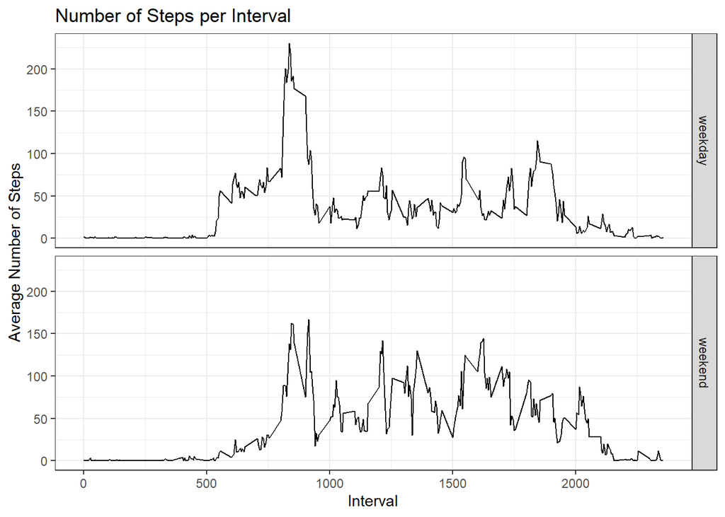

```r
library(tidyr)
library(ggplot2)
mn2 <- with(act_imputed,tapply(steps,list(interval,day),mean,na.rm=TRUE))
mn2_df <- data.frame(interval=rownames(mn2),steps=mn2)
rownames(mn2_df) <- seq(1,nrow(mn2_df))
mn2_df <- gather(mn2_df,"day","steps",-c(interval))
mn2_df$day <- with(mn2_df, sapply(day,function(x) strsplit(x,"\\.")[[1]][2]))
mn2_df$day <- as.factor(mn2_df$day)
mn2_df$interval <- as.numeric((mn2_df$interval))

ggplot(mn2_df, aes(interval,steps)) +
  geom_line() +
  facet_grid(day~.) +
  scale_fill_manual(breaks=c(0,500,1000,1500,2000)) +
  labs(title="Number of Steps per Interval",x="Interval",y="Average Number of Steps") +
  theme_bw()
```